# Cholera Trigger Analysis

Pauline N.

2025-08-19

## Introduction

This document contains analysis used to create an alert system using the WHO bulletins for cholera. It is done by country and checks for common indicators of an uptick in cases.

### Load Data

There are 3 columns with start of reporting period. It seems these columns are reporting on the same value and if one has a value, the rest are NA.

| Country | Event | Grade | Date notified to WCO | Start of reporting period | End of reporting period | Total cases | Cases Confirmed | Deaths | CFR | WeekNumber | Year | Month | Start of reporting period | End of reporting period | Start of reporting period | Unnamed: 10 | Date notified to WHO | YearWeek | WeekDate | Case Change |
| --- | --- | --- | --- | --- | --- | --- | --- | --- | --- | --- | --- | --- | --- | --- | --- | --- | --- | --- | --- | --- |
| Angola | Poliomyelitis (cVDPV2) | Grade 2 | 8-May-19 | 5-Apr-19 | NA | 71 | 71 | 0 | 0.0 | 5 | 2020 | 5 | NA | 22-Jan-20 | NA | NA | NA | 2020-5 | 2020-01-29 | NA |
| Benin | Dengue fever | Ungraded | 13-May-19 | 10-May-19 | NA | 26 | 14 | 2 | 7.7 | 5 | 2020 | 5 | NA | 29-Nov-19 | NA | NA | NA | 2020-5 | 2020-01-29 | NA |
| Benin | Meningitis | Ungraded | 6-Jan-20 | 9-Dec-19 | NA | 83 | 24 | 13 | 15.7 | 5 | 2020 | 5 | NA | 22-Jan-20 | NA | NA | NA | 2020-5 | 2020-01-29 | NA |
| Benin | Poliomyelitis (cVDPV2) | Grade 2 | 8-Aug-19 | 8-Aug-19 | NA | 6 | 6 | 0 | 0.0 | 5 | 2020 | 5 | NA | 22-Jan-20 | NA | NA | NA | 2020-5 | 2020-01-29 | NA |
| Burkina Faso | Humanitarian crisis | Grade 2 | 1-Jan-19 | 1-Jan-19 | NA | 0 | 0 | 0 | 0.0 | 5 | 2020 | 5 | NA | 27-Jan-20 | NA | NA | NA | 2020-5 | 2020-01-29 | NA |

### Clean and Prepare Data

| iso3 | date | event | start_date | cholera_cases | cholera_cfr | deaths |
| --- | --- | --- | --- | --- | --- | --- |
| AGO | 2025-01-22 | Cholera | 2025-01-07 | 58 | 8.6 | 5 |
| AGO | 2025-01-29 | Cholera | 2024-12-31 | 1216 | 3.9 | 48 |
| AGO | 2025-02-05 | Cholera | 2024-12-31 | 3043 | 3.3 | 101 |
| AGO | 2025-02-12 | Cholera | 2024-12-31 | 4107 | 3.8 | 147 |
| AGO | 2025-02-19 | Cholera | 2024-12-31 | 4914 | 3.7 | 180 |

First, checking if values tend to be increasing (cumulative) for each country Most of the values are greater than or equal to the one prior to it. (lowest being close to 90%), giving a strong indication of cumulative number of cases.

| iso3 | mean(rising_cases, na.rm = TRUE) |
| --- | --- |
| AGO | 0.8750000 |
| BDI | 0.9027778 |
| BEN | 0.9622642 |
| BFA | 1.0000000 |
| CIV | 1.0000000 |

### Additional Data Cleaning

- These weekdays for the date change
- these dates change depending on the year and weeks can change even within the year
- they tend to be between Mon-Wed
- tried to fill in values and seems there is an issue with the definition of weeks
- Also to replace values of 1 and correcting those with decimals especially those around other larger values
- Fill in the missing weeks

| date | event | start_date | cholera_cases | cholera_cfr | deaths | prev_date_diff |
| --- | --- | --- | --- | --- | --- | --- |
| AGO |  |  |  |  |  |  |
| 2025-01-22 | Cholera | 2025-01-07 | 58 | 8.6 | 5 | NA |
| 2025-01-29 | Cholera | 2024-12-31 | 1216 | 3.9 | 48 | 7 |
| 2025-02-05 | Cholera | 2024-12-31 | 3043 | 3.3 | 101 | 7 |
| 2025-02-12 | Cholera | 2024-12-31 | 4107 | 3.8 | 147 | 7 |
| 2025-02-19 | Cholera | 2024-12-31 | 4914 | 3.7 | 180 | 7 |

### Weekly Check

Quick check on how many weeks per country and year in dataset

| iso3 | min_weeks | max_weeks | mean_weeks |
| --- | --- | --- | --- |
| AGO | 25 | 25 | 25.0 |
| BDI | 5 | 51 | 29.0 |
| BEN | 1 | 23 | 13.5 |
| BFA | 7 | 13 | 10.0 |
| CIV | 5 | 5 | 5.0 |

Check for countries where dates are less than 7 days apart

| iso3 | count |
| --- | --- |
| AGO | 1 |
| BDI | 1 |
| CMR | 1 |
| COD | 2 |
| COM | 1 |

### Global Cholera Trigger Options:

1. Use the DRC trigger:
   - Level 3 alert sustained for 3 weeks
   - Level 3 defined as either:
     1. 4x increase compared to baseline, or
     2. Value above the 99th percentile
2. Use the old cumulative methodology (as included by Seth in the Signals system)
3. Use the Signals methodology:
   - Alert when current value is higher than any point in the past 12 months
4. Use a 3-year rolling average of weekly increases

Exploration of using the CFR or the Number of Deaths as well.

CERF Allocation Years

| iso3 | Year |
| --- | --- |
| AGO | 2025 |
| CMR | 2022 |
| CMR | 2020 |
| COM | 2024 |
| COD | 2025 |

## Methodology 1

Assumption: Values stay the same across weeks without data until reported otherwise and also making the data noncumulative.

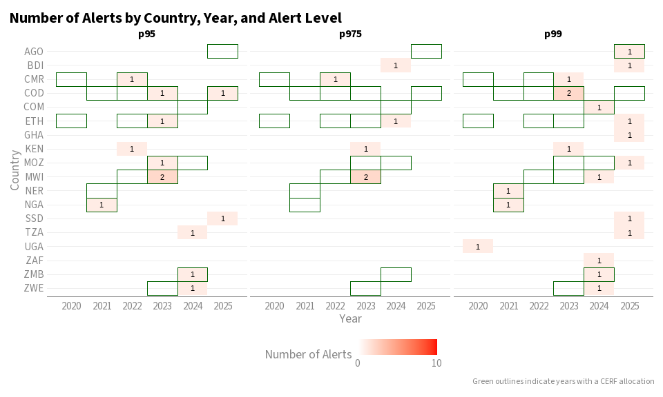

#### Comparison with CERF allocations

which alert level correlates with a CERF allocation (within 30 days before an alert or 90 days after)

| alert_level | n | n_window | prop_window |
| --- | --- | --- | --- |

| iso3 | date | event | start_date | cholera_cases | cholera_cfr | deaths | prev_date_diff | weekly_increase | p95 | p975 | p99 | year | alert_level | fold_increase | country_alloc_dates | nearest_allocation_date | time_diff_days | n_window |
| --- | --- | --- | --- | --- | --- | --- | --- | --- | --- | --- | --- | --- | --- | --- | --- | --- | --- | --- |

## Methodology 2

This method should use cumulative values.

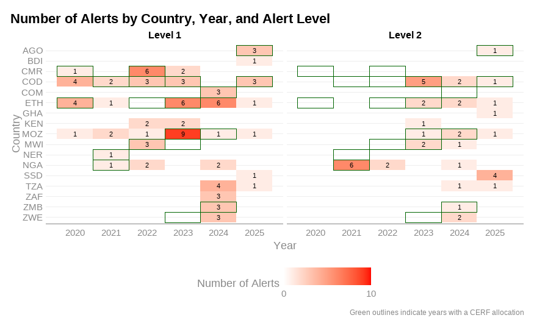

Comparison with CERF allocations

| n | n_window | prop_window |
| --- | --- | --- |
| 133 | 0 | 0 |

## Methodology 3

Remove zeros from weekly increases and adding check for no signals for the next 3 months

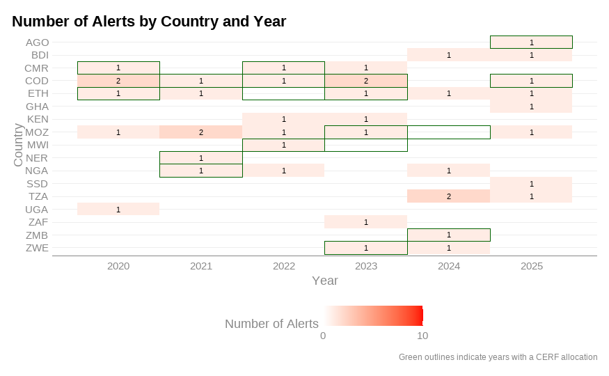

## Methodology 4

Create a 3-year rolling average of weekly caseload with a minimum of 500 cases.

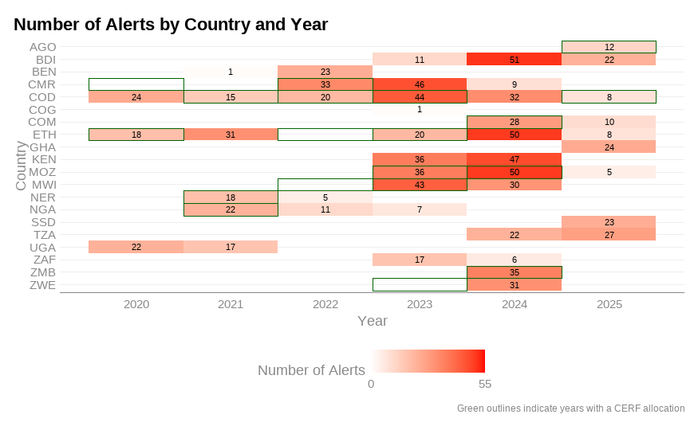

### Timelines for Method 4.

Challenges with the Rolling Average Method (3-year baseline)

1. Data Gaps and Inconsistencies
- Many countries lack continuous weekly data over 3 years.
- Missing weeks break the continuity, making the rolling mean less reliable.
2. Short Time Series
- For countries with only 1–2 years of data, the method results in a simple mean value.
3. Small spikes in cases can exceed the rolling mean, generating alerts even when there is no meaningful outbreak.
4. Multiple Alerts for the Same Event

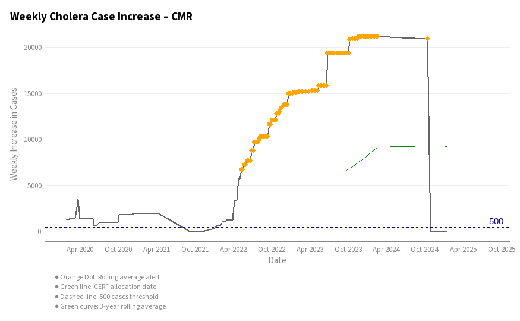

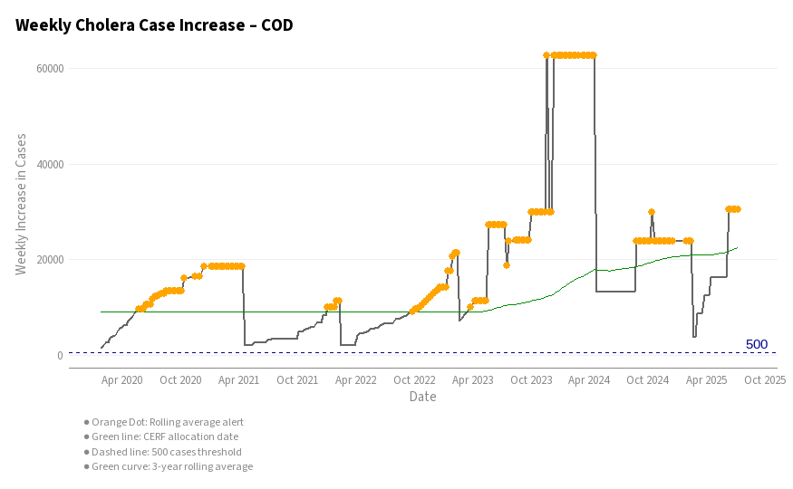

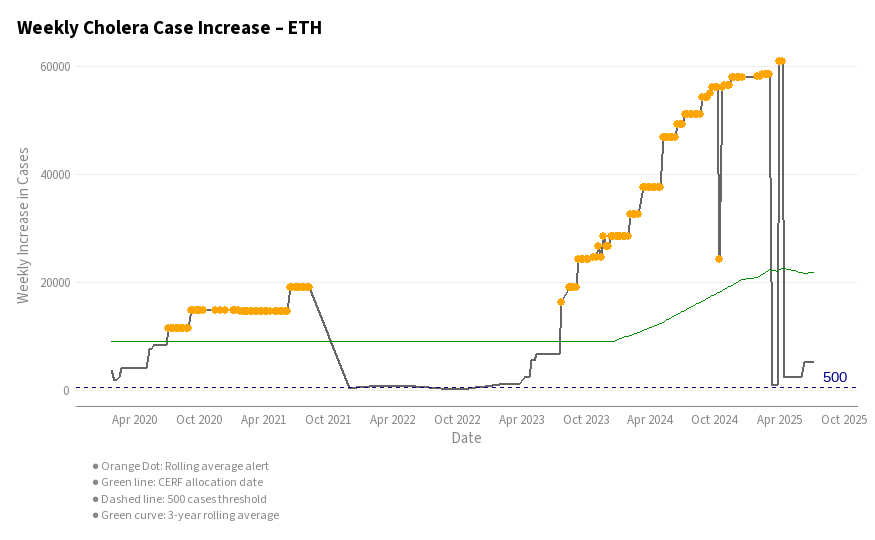

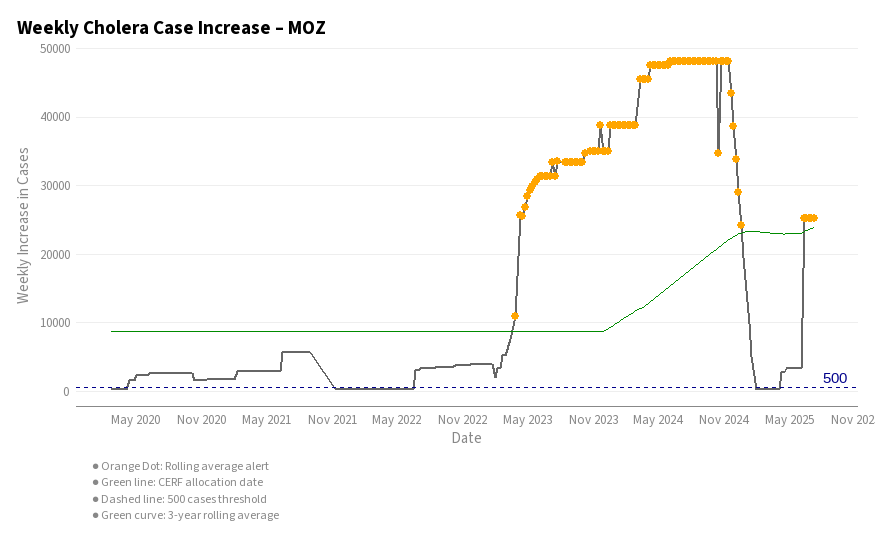

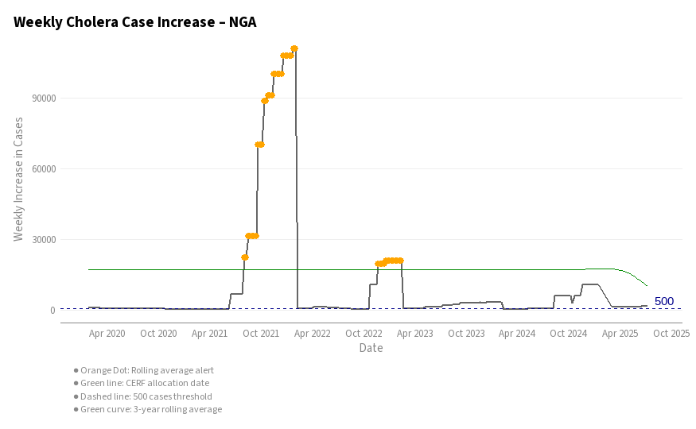

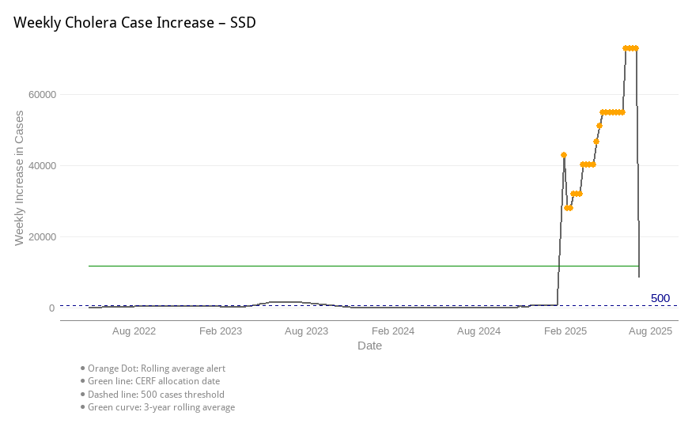

### Time Series of Cases by Country

A time series of cases by country showing the alert levels

| iso3 | date | event_df1 | start_date_df1 | cholera_cases_df1 | cholera_cfr_df1 | deaths_df1 | prev_date_diff_df1 | weekly_increase_df1 | p95 | p975 | p99 | year | alert_level | fold_increase | event_df2a | start_date_df2a | cholera_cases_df2a | cholera_cfr_df2a | deaths_df2a | prev_date_diff_df2a | weekly_increase_df2a | level | event | start_date | cholera_cases | cholera_cfr | deaths | prev_date_diff | weekly_increase | … |
| --- | --- | --- | --- | --- | --- | --- | --- | --- | --- | --- | --- | --- | --- | --- | --- | --- | --- | --- | --- | --- | --- | --- | --- | --- | --- | --- | --- | --- | --- | --- |
| AGO | 2025-01-22 | Cholera | 2025-01-07 | 58 | 8.6 | 5 | NA | NA | 5517 | 8124.5 | 9689 | 2025 | none | NA | NA |  | NA | NA | NA | NA | NA | NA | NA |  | NA | NA | NA | NA | NA | … |
| AGO | 2025-01-29 | Cholera | 2024-12-31 | 1216 | 3.9 | 48 | 7 | 1158 | 5517 | 8124.5 | 9689 | 2025 | none | NA | NA |  | NA | NA | NA | NA | NA | NA | Cholera | 2024-12-31 | 1216 | 3.9 | 48 | 7 | 1158 | … |
| AGO | 2025-02-05 | Cholera | 2024-12-31 | 3043 | 3.3 | 101 | 7 | 1827 | 5517 | 8124.5 | 9689 | 2025 | none | 1.5777202 | NA |  | NA | NA | NA | NA | NA | NA | NA |  | NA | NA | NA | NA | NA | … |
| AGO | 2025-02-12 | Cholera | 2024-12-31 | 4107 | 3.8 | 147 | 7 | 1064 | 5517 | 8124.5 | 9689 | 2025 | none | 0.5823755 | NA |  | NA | NA | NA | NA | NA | NA | NA |  | NA | NA | NA | NA | NA | … |
| AGO | 2025-02-19 | Cholera | 2024-12-31 | 4914 | 3.7 | 180 | 7 | 807 | 5517 | 8124.5 | 9689 | 2025 | none | 0.7584586 | NA |  | NA | NA | NA | NA | NA | NA | NA |  | NA | NA | NA | NA | NA | … |
| AGO | 2025-02-26 | Cholera | 2024-12-31 | 5749 | 3.5 | 204 | 7 | 835 | 5517 | 8124.5 | 9689 | 2025 | none | 1.0346964 | NA |  | NA | NA | NA | NA | NA | NA | NA |  | NA | NA | NA | NA | NA | … |

## Final proposal

```
- Watch alert: highest value in the last 12 months
- Warning alert: 99th percentile
```

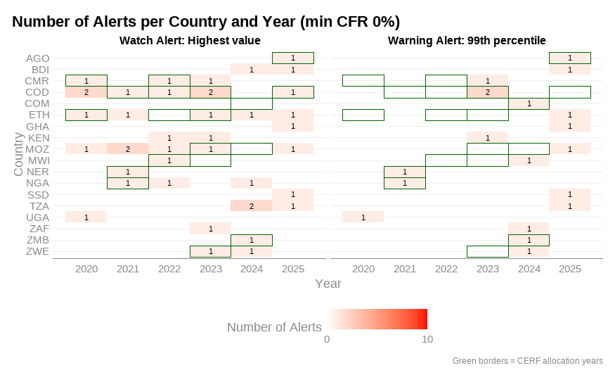

#### Plotting for a specific country

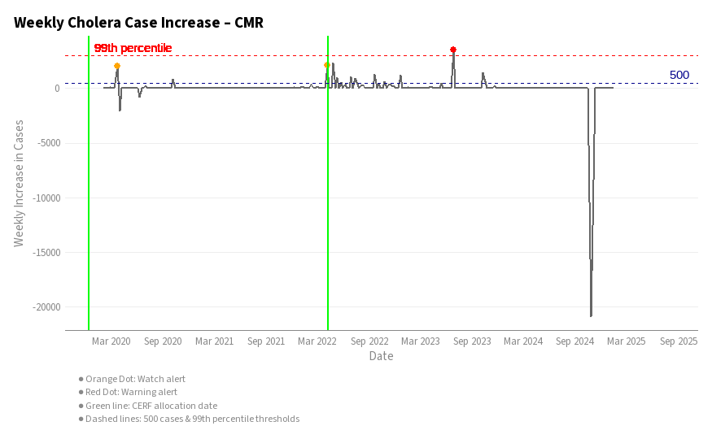

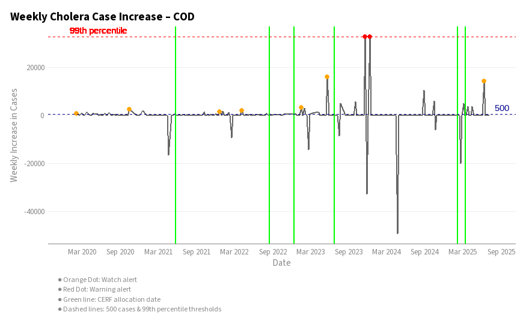

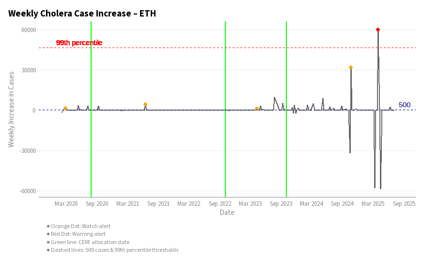

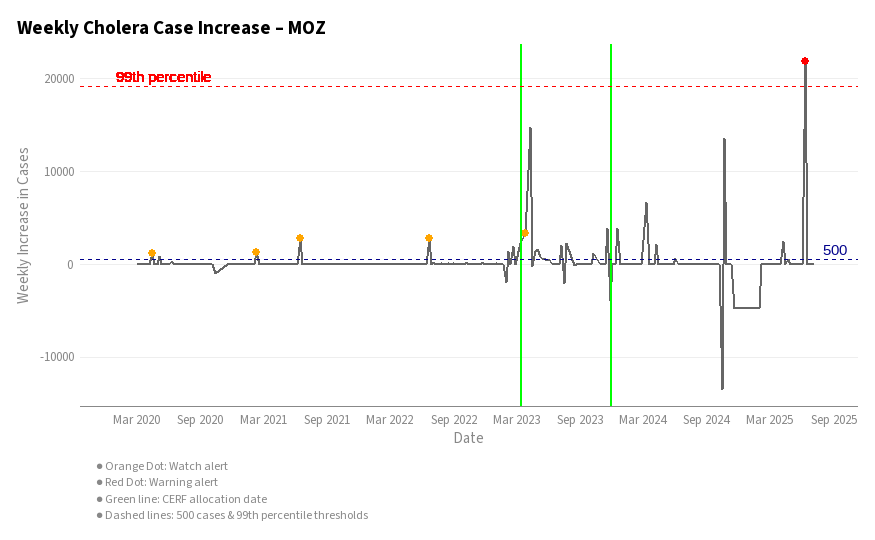

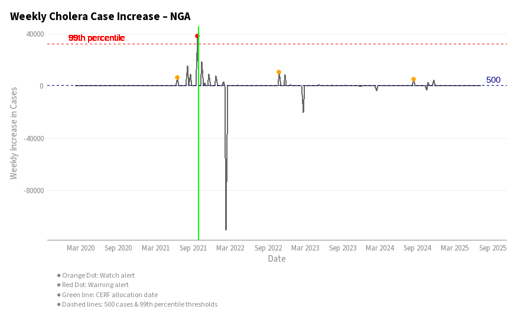

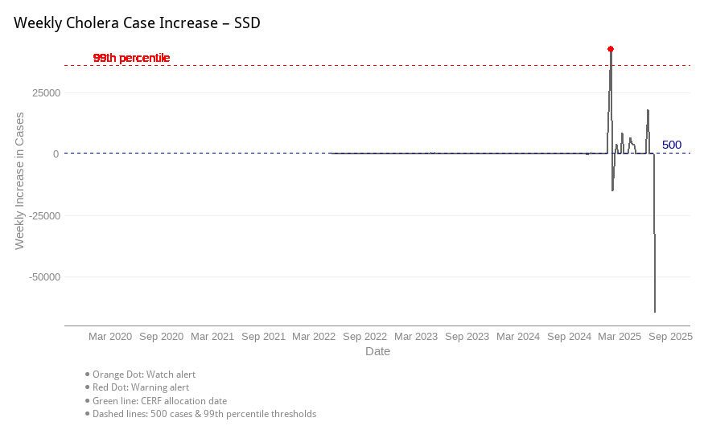

#### Plots with CFR

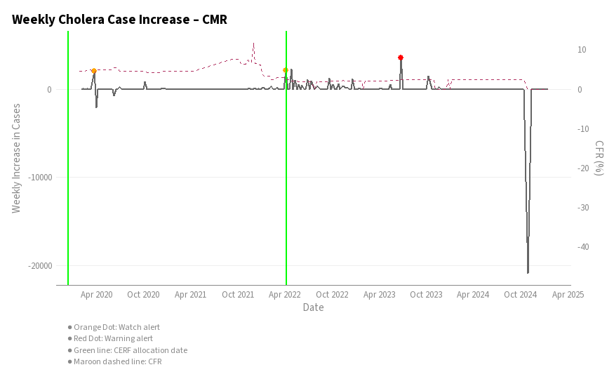

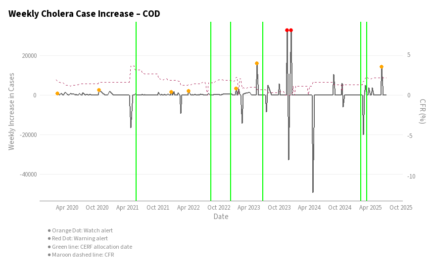

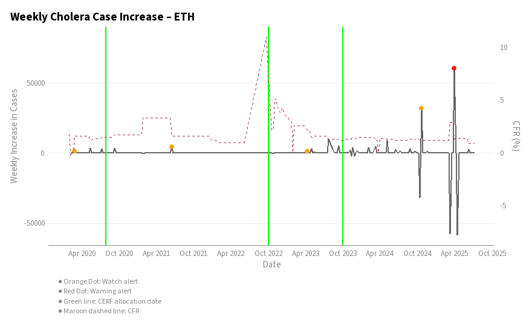

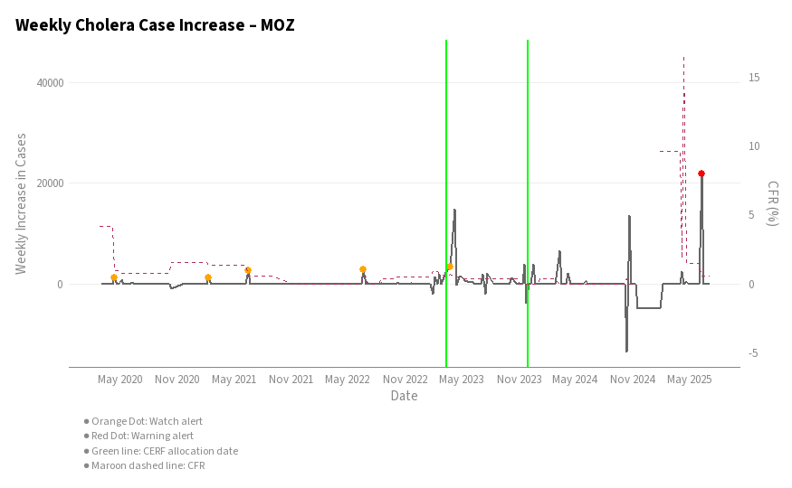

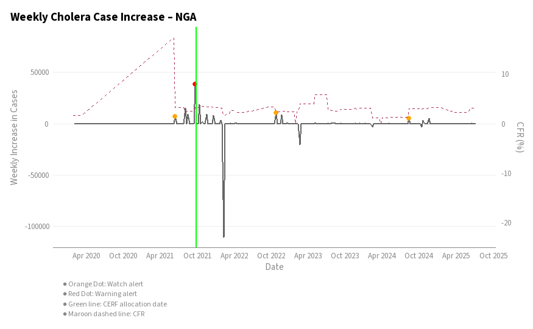

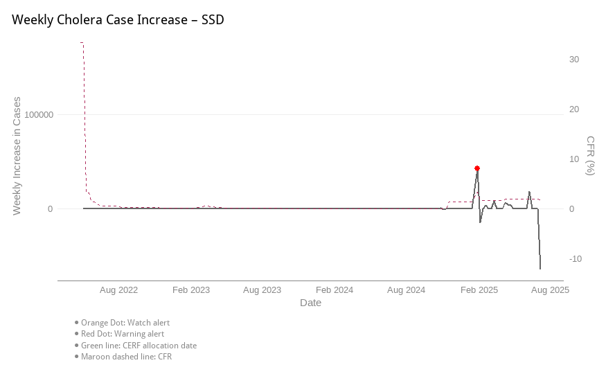